# Actividad 1: Exploración y preprocesamiento de datos

Jorge Solán Morote

2025-03-28

Para la elaboración de esta actividad serán necesarias las siguientes librerías

```r
#install.packages(c("openxlsx","VIM","stringr","dplyr","knitr","ggplot2"))
library(openxlsx)
library(VIM)
library(stringr)
library(dplyr)
library(knitr)
library(ggplot2)
```

### 1. Preparación del conjunto de datos

#### 1.1 Cargar el archivo de datos

```r
sleephealth <- read.xlsx("sleephealth.xlsx")
str(sleephealth)
```

```
## 'data.frame':    374 obs. of  13 variables:
##  $ Person.ID              : num  1 2 3 4 5 6 7 8 9 10 ...
##  $ Gender                 : chr  "Male" "Male" "Male" "Male" ...
##  $ Age                    : chr  "27" "28" "28" "28" ...
##  $ Occupation             : chr  "Software Engineer" "Doctor" "Doctor" "Sales Representative" ...
##  $ Sleep.Duration         : chr  "6.1" "6.2" "6.2" "5.9" ...
##  $ Quality.of.Sleep       : num  6 6 6 4 4 4 6 7 7 7 ...
##  $ Physical.Activity.Level: num  42 60 60 30 30 30 40 75 75 75 ...
##  $ Stress.Level           : num  6 8 8 8 8 8 7 6 6 6 ...
##  $ BMI.Category           : chr  "Overweight" "Normal" "Normal" "Obese" ...
##  $ Blood.Pressure         : chr  "126/83" "125/80" "125/80" "140/90" ...
##  $ Heart.Rate             : num  77 75 75 85 85 85 82 70 70 70 ...
##  $ Daily.Steps            : num  4200 10000 10000 3000 3000 3000 3500 8000 8000 8000 ...
##  $ Sleep.Disorder         : chr  "None" "None" "None" "Sleep Apnea" ...
```

#### 1.2 Nombre de las columnas

Cambiamos los nombres de las columnas como nos indica el enunciado

```r
colnames(sleephealth) <- c("ID", "Gender","Age","Occupation", "SH", "SQ", "PHY", "Stress", "BMI", "BP", "HR", "Steps", "SD")
colnames(sleephealth)
```

```
##  [1] "ID"         "Gender"     "Age"        "Occupation" "SH"
##  [6] "SQ"         "PHY"        "Stress"     "BMI"        "BP"
## [11] "HR"         "Steps"      "SD"
```

### 2 Normalización de formatos en variables categóricas

Según las diferentes variables podemos hacer la siguiente separación:  
Factor: Gender, Occupation, BMI.Category, Sleep.Disorder  
Ordered (Porque están en escala del 1-10): Quality.of.Sleep, Stress.Level

```r
sleephealth$Gender <- as.factor(sleephealth$Gender)
sleephealth$BMI <- as.factor(sleephealth$BMI)
sleephealth$SD <- as.factor(sleephealth$SD)
sleephealth$SQ <- as.ordered(sleephealth$SQ)
sleephealth$Stress <- as.ordered(sleephealth$Stress)
```

En la introducción también se comenta lo siguiente:  
“Los nombres de las ocupaciones comienzan con mayúscula. Si hay categorías con el mismo concepto y diferentes nombres, deben unificarse los nombres.”  
Antes de transformarla en Factor, vamos a corregir la columna de “Occupation”.  
Primero miramos cómo está actualmente y los valores que tienen

```r
unique(sleephealth$Occupation)
```

```
##  [1] "Software Engineer"    "Doctor"               "Sales Representative"
##  [4] "Teacher"              "Nurse"                "Engineer"
##  [7] "Accountant"           "Scientist"            "Lawyer"
## [10] "Salesperson"          "engineer"             "Manager"
```

Ponemos todos con la primera letra en mayúscula y agrupamos por el mismo concepto.  
Los de la salud juntos, los ingenieros y los de ventas.

```r
sleephealth$Occupation <- str_to_title(sleephealth$Occupation)
sleephealth$Occupation[sleephealth$Occupation %in% c("Doctor", "Nurse")] <- "Health"
sleephealth$Occupation[sleephealth$Occupation %in% c("Engineer", "Software Engineer")] <- "Engineer"
sleephealth$Occupation[sleephealth$Occupation %in% c("Sales Representative", "Salesperson")] <- "Sales"
```

Por último, como con los anteriores, transformamos a factor

```r
sleephealth$Occupation <- as.factor(sleephealth$Occupation)
levels(sleephealth$Occupation)
```

```
## [1] "Accountant" "Engineer"   "Health"     "Lawyer"     "Manager"
## [6] "Sales"      "Scientist"  "Teacher"
```

Una vez cambiados los tipos nos aseguramos mirando de nuevo la estructura de la tabla

```
## 'data.frame':    374 obs. of  13 variables:
##  $ ID        : num  1 2 3 4 5 6 7 8 9 10 ...
##  $ Gender    : Factor w/ 2 levels "Female","Male": 2 2 2 2 2 2 2 2 2 2 ...
##  $ Age       : chr  "27" "28" "28" "28" ...
##  $ Occupation: Factor w/ 8 levels "Accountant","Engineer",..: 2 3 3 6 6 2 8 3 3 3 ...
##  $ SH        : chr  "6.1" "6.2" "6.2" "5.9" ...
##  $ SQ        : Ord.factor w/ 6 levels "4"<"5"<"6"<"7"<..: 3 3 3 1 1 1 3 4 4 4 ...
##  $ PHY       : num  42 60 60 30 30 30 40 75 75 75 ...
##  $ Stress    : Ord.factor w/ 6 levels "3"<"4"<"5"<"6"<..: 4 6 6 6 6 6 5 4 4 4 ...
##  $ BMI       : Factor w/ 4 levels "Normal","Normal Weight",..: 4 1 1 3 3 3 3 1 1 1 ...
##  $ BP        : chr  "126/83" "125/80" "125/80" "140/90" ...
##  $ HR        : num  77 75 75 85 85 85 82 70 70 70 ...
##  $ Steps     : num  4200 10000 10000 3000 3000 3000 3500 8000 8000 8000 ...
##  $ SD        : Factor w/ 3 levels "Insomnia","None",..: 2 2 2 3 3 1 1 2 2 2 ...
```

### 3 Inconsistencias en variables cuantitativas

Viendo la tabla anterior, vemos algunas variables que se han tranformado como carácter cuando deberían ser numéricas, entre ellas tenemos Age, SH y BP. (Ponemos SH como variable aparte para usarla y explicarla en el siguiente apartado)

```r
sleephealth$Age <- as.numeric(sleephealth$Age)
SH_var <- as.numeric(sleephealth$SH)
```

En la columna BP hay que realizar una separación en 2 nuevas columnas:

Presión sistólica como el valor anterior al “/”.  
Presión diástola como valor posterior al “/”.

```r
bd_split <- str_split(sleephealth$BP, "/", , simplify = TRUE)
sleephealth$BPsyst <- as.numeric(bd_split[, 1])
sleephealth$BPdias <- as.numeric(bd_split[, 2])
# Si quisieramos eliminar la columna de BP
#sleephealth$BP <- NULL
```

### 4 Valores erróneos o atípicos

#### 4.1 Valores erróneos

Dentro de esta categoría dentro de los datos solo nos encontramos un caso, aquellos valores de duración del sueño que se han puesto con comas como separador en vez de el punto.

En el código del apartado 3 nos salía además el mensaje:

```
Warning: NAs introducidos por coerción
```

Estos valores podemos mirarlos con:

```r
sleephealth$SH[is.na(SH_var)]
```

```
## [1] "7,85" "7,66"
```

Podríamos transformar estos a valores válidos sustituyendo las ‘,’ por ‘.’, pero se nos indica en el enunciado transformarlos a NAs.  
Otra de las cosas que podríamos mirar es que no haya valores de edad, pasos, ritmo cardíaco o presión menores que 0, que sean negativos, ya que no tendrían sentido y son erróneos.

```r
sleephealth$SH <- SH_var
sleephealth$Age[sleephealth$Age<0] <- NA
sleephealth$SH[sleephealth$SH<0] <- NA
sleephealth$PHY[sleephealth$PHY<0] <- NA
sleephealth$Steps[sleephealth$Steps<0] <- NA
sleephealth$BPsyst[sleephealth$BPsyst<0] <- NA
sleephealth$BPdias[sleephealth$BPdias<0] <- NA
```

#### 4.2 Valores atípicos

Una manera sencilla de mirar los valores atípicos es usar la función boxplot, que aparte de verlos gráficamente, también podemos mirar directamente los atípicos.

```r
boxplot.stats(sleephealth$Age)$out
```

```
## [1] 999 999 999  73 999 999 999
```

```r
boxplot.stats(sleephealth$SH)$out
```

```
## numeric(0)
```

```r
boxplot.stats(sleephealth$PHY)$out
```

```
## numeric(0)
```

```r
boxplot.stats(sleephealth$Steps)$out
```

```
## numeric(0)
```

```r
boxplot.stats(sleephealth$BPsyst)$out
```

```
## numeric(0)
```

```r
boxplot.stats(sleephealth$BPdias)$out
```

```
## numeric(0)
```

Con esto nos fijamos que la variable de edad tiene varios valores atípicos, el 999 y el 73.  
El primero de estos es un “valor centinela” como se explica en “Recursos de aprendizaje A1”, con lo que podemos ponerlo como NA, el valor 73 podemos estudiarlo mejor visualizándolo y de ahí decidimos qué hacer con él.

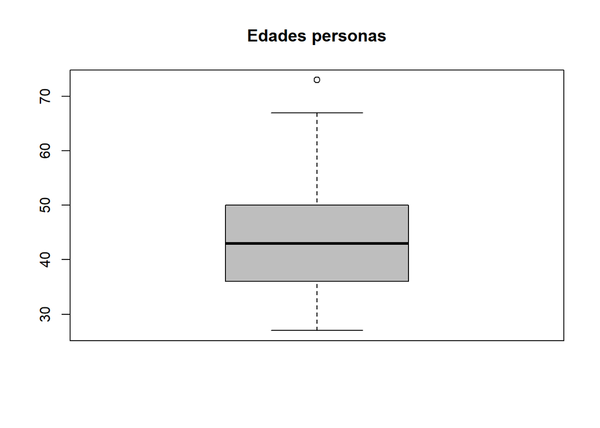

```r
sleephealth$Age[sleephealth$Age == 999] <- NA
boxplot(sleephealth$Age,main="Edades personas", col="gray")
```

En este caso no veo necesario hacer nada con ese valor ya que es normal, no se dista tampoco mucho de las edades más cercanas a él.

### 5. Imputación

Para este apartado primero debemos seleccionar todas las variables numéricas con valor NA.

Primero quitamos la columna ID, por la imputación posterior.

```r
num_col_ID <- sleephealth[, sapply(sleephealth, is.numeric)]
num_col <- num_col_ID[, !colnames(num_col_ID) %in% "ID"]
na <- is.na(num_col_ID)
```

Una vez tenemos seleccionadas las columnas, debemos realizar su imputación, basada en los 3 vecinos más cercanos.

```r
imputed <- kNN(sleephealth, variable = colnames(num_col), k = 3)
```

Al realizar la imputación simplemente se nos pide visualizar los resultados y añadirlos a la tabla original.

```r
na_values <- sleephealth[rowSums(na) > 0, colnames(num_col_ID)]
imputed_values <- imputed[rowSums(na) > 0, colnames(num_col_ID)]
sleephealth[rowSums(na) > 0, colnames(num_col_ID)] <- imputed_values
# Valores antes de imputarlos
print(as.data.frame(na_values), row.names = FALSE)
```

```
##   ID Age  SH PHY HR Steps BPsyst BPdias
##   25  30  NA  75 70  8000    120     80
##   42  NA 7.7  75 70  8000    120     80
##   52  NA 7.5  45 70  8000    120     80
##   54  32  NA  75 70  8000    120     80
##   76  NA 6.0  30 72  5000    125     80
##   87  NA 7.2  60 65  5000    125     80
##  154  NA 7.2  60 68  8000    130     85
##  180  NA 7.8  90 70  8000    130     85
##  245  NA 6.3  45 72  6000    130     85
##  305  NA 6.1  90 75 10000    140     95
##  334  NA 8.4  30 65  5000    125     80
```

```r
# Valores tras imputarlos
print(as.data.frame(imputed_values), row.names = FALSE)
```

```
##   ID Age  SH PHY HR Steps BPsyst BPdias
##   25  30 7.7  75 70  8000    120     80
##   42  31 7.7  75 70  8000    120     80
##   52  35 7.5  45 70  8000    120     80
##   54  32 7.7  75 70  8000    120     80
##   76  33 6.0  30 72  5000    125     80
##   87  35 7.2  60 65  5000    125     80
##  154  39 7.2  60 68  8000    130     85
##  180  42 7.8  90 70  8000    130     85
##  245  44 6.3  45 72  6000    130     85
##  305  50 6.1  90 75 10000    140     95
##  334  54 8.4  30 65  5000    125     80
```

### 6. Correlaciones

#### 6.1 Matriz de correlaciones

Para mirar la matriz de correlaciones, sin el ID, hacemos lo siguiente:

```r
num_col_ID <- sleephealth[, sapply(sleephealth, is.numeric)]
num_col <- num_col_ID[, !colnames(num_col_ID) %in% "ID"]
res <- cor(num_col)
round(res, 2)
```

```
##          Age    SH  PHY    HR Steps BPsyst BPdias
## Age     1.00  0.34 0.17 -0.23  0.05   0.57   0.56
## SH      0.34  1.00 0.21 -0.52 -0.04  -0.18  -0.17
## PHY     0.17  0.21 1.00  0.14  0.77   0.27   0.38
## HR     -0.23 -0.52 0.14  1.00 -0.03   0.29   0.27
## Steps   0.05 -0.04 0.77 -0.03  1.00   0.10   0.24
## BPsyst  0.57 -0.18 0.27  0.29  0.10   1.00   0.97
## BPdias  0.56 -0.17 0.38  0.27  0.24   0.97   1.00
```

Del resultado podemos sacar varios puntos a tener en cuenta con algunos valores cercanos a +/- 1:

- La presión sistólica y diastólica tienen una correlación casi de 1, con que presentan una dependencia lineal en sentido directo. Tiene sentido al tratarse de presión sanguínea de una misma persona.
- Entre la actividad física y el número de pasos diarios observamos también una dependencia lineal directa con valor de 0.77. Lógico si pensamos que los pasos diarios también son en parte una actividad física.
- Por último, aunque no es tan clara existen 3 relaciones más 2 dependencias directas que relacionan la edad con la presión sanguínea, diciéndonos que a menor edad menos presión sanguínea suele tener la gente y viceversa.
- Y una dependencia indirecta, no tan clara como las dos primeras ya que esta presenta un valor de -0.52, entre la duración del sueño y el ritmo cardíaco. De lo que podemos decir que, cuanto más duerme la gente, menor es su ritmo cardíaco, lo que puede tener sentido si tuviéramos en cuenta también la calidad del sueño.

#### 6.2 Cálculo de las correlaciones

Para este cálculo me he basado en la formula que presentan en la siguiente [web](https://www.jmp.com/es/statistics-knowledge-portal/what-is-correlation/correlation-coefficient), para hacer una función que me dé la correlación entre dos vectores.

```r
cor_pearson <- function(x, y) {

  mean_x <- mean(x)
  mean_y <- mean(y)

  cov_xy <- sum((x - mean_x) * (y - mean_y))

  var_x <- sum((x - mean_x)^2)
  var_y <- sum((y - mean_y)^2)

  return(cov_xy / sqrt(var_x * var_y))
}
```

Con esta función propia podemos probar algún valor a ver si es igual al de la función cor.

```r
res0 <- cor_pearson(sleephealth$Age, sleephealth$SH)
res1 <- cor_pearson(sleephealth$Steps, sleephealth$HR)
round(res0,2)
```

```
## [1] 0.34
```

```r
round(res1,2)
```

```
## [1] -0.03
```

Después de probar dos relaciones podemos dar por buena la función.

### 7 Análisis descriptivo y visual

#### 7.1 Tabla resumen de tendencia central y variabilidad de HR según SD

Para elaborar la tabla he necesitado consultar la documentación de kable para la tabla y la de group_by y summarise para la preparación de los datos, además en estos últimos había algunos ejemplos de uso.

```r
summary_table <- sleephealth %>%
  group_by(SD) %>%
  summarise(
    Mean_SH = round(mean(SH), 4),
    SD_SH = round(sd(SH), 4),
    Mean_SQ = round(mean(as.numeric(SQ)), 4),
    SD_SQ = round(sd(as.numeric(SQ)), 4),
    Mean_HR = round(mean(HR), 4),
    SD_HR = round(sd(HR), 4),
    Mean_Stress = round(mean(as.numeric(Stress)), 4),
    SD_Stress = round(sd(as.numeric(Stress)), 4)
  )

kable(summary_table, caption = "Tendencia Central y Dispersión por Trastorno del Sueño (SD)")
```

Tendencia Central y Dispersión por Trastorno del Sueño (SD)

| SD | Mean_SH | SD_SH | Mean_SQ | SD_SQ | Mean_HR | SD_HR | Mean_Stress | SD_Stress |
| --- | --- | --- | --- | --- | --- | --- | --- | --- |
| Insomnia | 6.5896 | 0.3872 | 3.5325 | 0.8043 | 70.4675 | 4.9486 | 3.8701 | 1.4631 |
| None | 7.3584 | 0.7323 | 4.6256 | 0.9751 | 69.0183 | 2.6578 | 3.1142 | 1.5915 |
| Sleep Apnea | 7.0321 | 0.9748 | 4.2051 | 1.6464 | 73.0897 | 5.1173 | 3.6667 | 2.3336 |

#### **7.2 Gráfico de medias según HR y Occupation**

Para esta función he mirado documentación de la librería de [ggplot2](https://ggplot2.tidyverse.org/), donde también habia una [cheatsheet](https://github.com/rstudio/cheatsheets/blob/main/data-visualization.pdf) con las diferentes visualizaciones. Y también he consultado el apartado de [labs](https://ggplot2.tidyverse.org/reference/labs.html) para dar más contexto al gráfico

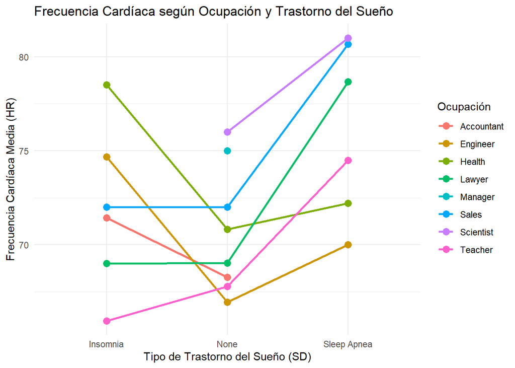

```r
graph_mean <- function(data) {

  summary <- data %>%
    group_by(SD, Occupation) %>%
    summarise(Mean_HR = mean(HR), .groups = "drop")

  summary$SD <- as.factor(summary$SD)

  plot <- ggplot(summary, aes(x = SD, y = Mean_HR, group = Occupation, color = Occupation)) +
    geom_line(linewidth = 1) +
    geom_point(size = 3) +
    labs(title = "Frecuencia Cardíaca según Ocupación y Trastorno del Sueño",
         x = "Tipo de Trastorno del Sueño (SD)",
         y = "Frecuencia Cardíaca Media (HR)",
         color = "Ocupación") +
    theme_minimal()

  # Devolver el gráfico
  return(plot)
}
graph_mean(sleephealth)
```

Viendo un poco las tendencias generales que cogen los valores de la gráfica podemos agrupar más las ocupaciones que habíamos realizado en el apartado 2. Haciendo la típica separación de estudios, ciencias o letras. Lo ponemos en variable temporal para dejar la tabla final con la primera separación presentada.

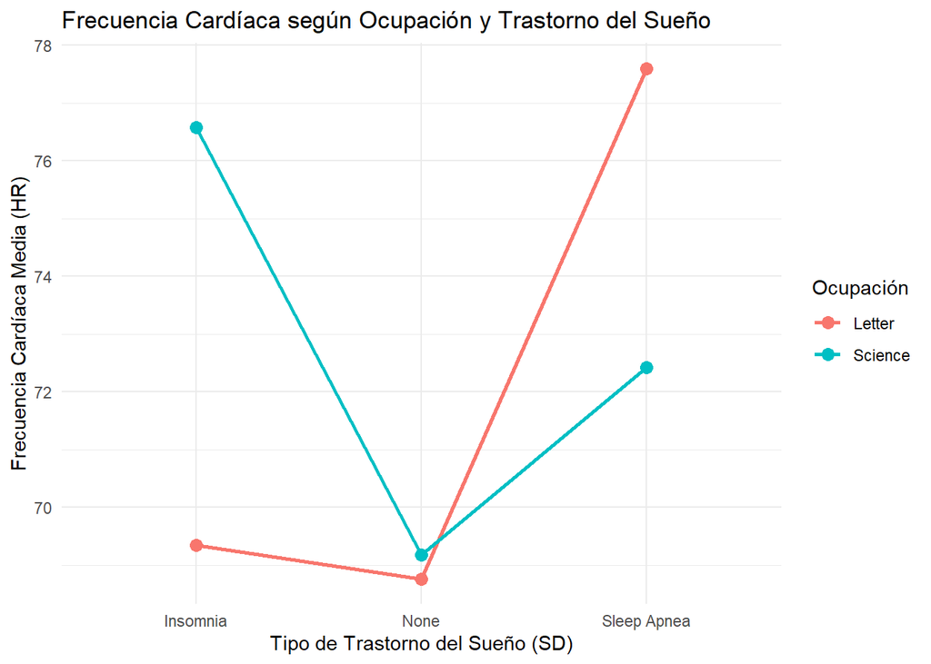

```r
temp <- sleephealth
temp$Occupation <- as.character(temp$Occupation)
temp$Occupation[temp$Occupation %in% c("Engineer", "Health","Scientist")] <- "Science"
temp$Occupation[temp$Occupation %in% c("Accountant","Sales", "Manager","Lawyer","Teacher" )] <- "Letter"
temp$Occupation <- as.factor(temp$Occupation)
graph_mean(temp)
```

Así podemos decir que las personas sin trastornos del sueño, suelen tener una frecuencia cardíaca baja.  
Las personas de trabajos más relacionados con la carrera de ciencias que tienen insomnio suelen tener un HR muy elevado comparado con aquellas personas con trabajos más relacionados la rama de letras que también presentan dicho trastorno, sin embargo, estas últimas tienen un HR más elevado que el primer grupo si ambos grupos tienen apnea del sueño.

### 8 Archivo final

Para sacar el archivo final simplemente ejecutar lo siguiente

```r
# Si se quiere en xlsx como estaba al principio
#write.xlsx(sleephealth, "solan_sleephealth_clean.csv")
write.csv(sleephealth, "solan_sleephealth_clean.csv", row.names = FALSE)
```